# Geoprostorová data

Michal Frankl

Masarykův ústav a Archiv AV

Evropská infrastruktura pro výzkum holokaustu

## Geoprostorová data (geospatial data)

- spojena s konkrétními místy na zemském povrchu nebo jeho blízkosti (lze ale hovořit i o dalších vesmírných tělesech)
- obvykle obsahují souřadnice (zeměpisnou šířku a délku), které umožňují jejich přesné umístění v prostoru
- případně další atributy dané lokality (např. výška nad mořem nebo druh krajiny)
- Vlastní zkušenost s geodaty?

## Mapy ve výzkumu a vzdělávání o holokaustu

[figure not shown]

Vienna Wiesenthal Institute for Holocaust Studies

[figure not shown]

Eichmann Trial (Szczepan, Aleksandra. ‘Terra Incognita? Othering East-Central Europe in Holocaust Studies’)

[figure not shown]

Gilbert, Martin. Atlas of the Holocaust. 3. vyd. Pergamon Press - Steimatzky, 1989.

[figure not shown]

US Holocaust Memorial Museum

[figure not shown]

"Nacistická perzekuce", Český historický atlas (http://cha.fsv.cvut.cz/)

[figure not shown]

Tim Cole, Alberto Giordano, *The Budapest Ghetto dataset*

## Dějiny holokaustu v prostoru města

Příklady

- Memento Wien: https://memento.wien/
- Databáze varšavského ghetta: https://getto.pl/
- MemoMap Praha: https://memomap.cz/

Otázky

- Jaké typy dat využívají?
- Jak zobrazení na mapě mění vnímání městského prostoru?

## Rasterová data

[figure not shown]

- "obrázek"

## Georeferencování

- online nástroje (např. OldMapsOnline)

[figure not shown]

## Georeferencování

- desktopové GIS (např. QGIS, ArcGIS)

[figure not shown]

## Georeferencování

[figure not shown]

## Georeferencování

[figure not shown]

## Vektorová data

[figure not shown]

- geometrické tvary: body, čáry, mnohoúhelníky
- geokódování
  - Mapy.cz, Google Maps, Geonames.org
  - Služby: např. OpenStreetMap - Nominatim API

```python
from geopy.geocoders import Nominatim
geolocator = Nominatim(user_agent="MUNIclass")
location = geolocator.geocode("Praha Nekázanka 4")
print(location.latitude, location.longitude)
```

```
50.0854163 14.427348
```

```python
import folium
m = folium.Map(location=(location.latitude, location.longitude), zoom_start="18")
folium.Marker(
    location=[location.latitude, location.longitude],
    popup="Nekázanka 4, Praha",
    icon=folium.Icon(color="red", icon="info-sign")
).add_to(m)
m
```

Make this Notebook Trusted to load map: File -> Trust Notebook

[interactive chart not shown]

## Typy geografických dat - rozšíření

**Podle obsahu:**

- **Topografická data** – zobrazují fyzický povrch (terén, vodstvo, sídla)
- **Tematická data** – zaměřená na konkrétní jev nebo fenomén

**Podle měřítka:**

- **Makroúroveň:** kontinenty, státy, regiony
- **Mikroúroveň:** ulice, parcely, konkrétní domy

**Podle časové dimenze:**

- **Statická data** – vztahují se k jednomu období
- **Dynamická data** – sledují změnu v čase

**Podle zdroje a původu:**

- **Primární data** – přímé měření, mapování, dokumenty
- **Odvozená data** – vzniklá z kombinace více zdrojů

## Reprezentace prostoru

**Souřadnicové systémy (mapové projekce)**  
způsob, jak se 3D povrch převádí do 2D mapy

https://thetruesize.com

[figure not shown]

## Článek Tim Cole, Alberto Giordano, *Digital Mapping*

- Čím se zabývali?
- Jaká jsou podle nich specifika práce s GISem?
- Jak to ovlivnilo jejich vlastní výzkum?

[figure not shown]

Knowles, Anne Kelly, Tim Cole, a Alberto Giordano, ed. Geographies of the Holocaust. Bloomington: Indiana University Press, 2014, s. 136.

## Holocaust Studies jako příklad prostorového obratu v humanitních vědách

- Holocaust Geographies Collaborative: transdisciplinární spolupráce
- Kritická kartografie
- Sociální konstrukce prostoru
- Humánní geografie

[figure not shown]

Židovské muzeum v Praze

[figure not shown]

Židovské muzeum v Praze

## Evropská infrastruktura pro výzkum holokaustu (EHRI)

- Výzkumná infrastruktura: zpřístupňuje data a služby, školení a workshopy
- Služby:
  - EHRI Portal (https://portal.ehri-project.eu/)
  - EHRI editions
  - EHRI Document Blog (https://blog.ehri-project.eu/)
  - EHRI Research Guides (https://portal.ehri-project.eu/guides)
  - EHRI Dashboard (https://dashboard.ehri-project-stage.eu/)
  - EHRI Training site and MOOC
- Český uzel EHRI: https://ehri.cz/

[figure not shown]

## Zadání pro samostatnou práci

### 1. Rozbor propojení svědectví a mapy

- Svědectví pamětníků holokaustu, edice dokumentů EHRI:
  - Early Holocaust Testimony: https://early-testimony.ehri-project.eu/
  - Documentation Campaign: https://documentation-campaign.ehri-project.eu/
- Požadavky:
  - informace, které svědectví jste četl/a
  - rozbor, nakolik bylo možné individuální příběh na mapě sledovat, respektive jaké aspekty zkušenosti holokaustu na mapě zobrazeny nebyly
  - reflexe, jak by bylo možné zobrazení této zkušenosti na mapě vylepšit

[figure not shown]

## Zadání pro samostatnou práci

### 2. Tvorba mapy

- EHRI Geospatial Repository: https://geodata.ehri-project.eu
- Požadavky:
  - alespoň dvě vrstvy
  - popis cíle (proč právě zvolené vrstvy)
  - reflexe procesu práce s daty (včetně nedostatků, co chybí pro pochopení historické zkušenosti)

### EHRI Geospatial Repository: https://geodata.ehri-project.eu/

- reakce na potřeby výzkumníků: data a školení
- otevřená data, pricipy FAIR
- geoprostorové standardy a služby (WFS, WMS, ...)
- různé způsoby využití
- spuštěna 2023, stále v rané fázi

[figure not shown]

### EHRI Geospatial Repository: https://geodata.ehri-project.eu/

[figure not shown]

### EHRI Geospatial Repository: https://geodata.ehri-project.eu/

[figure not shown]

### EHRI Geospatial Repository: https://geodata.ehri-project.eu/

[figure not shown]

### EHRI Geospatial Repository: https://geodata.ehri-project.eu/

[figure not shown]

### Google My Maps: https://www.google.com/maps/d/

[figure not shown]

### uMap (OpenStreetMap): https://umap.openstreetmap.fr/

[figure not shown]

## Náznak datové analýzy: Stolpersteiny v Praze

[figure not shown]

- Odpovídá jejich prostorová distribuce místům, kde Židé v Praze žili před deportací?
- Lze identifikovat preferenci pro prostory považované za "židovské" nebo pro bohatší čtvrti?

### Načtení hranic historických pražských čtvrtí

```python
districts = ehri_wfs("ehri:MGS-prague_districts_borders-v1")
districts
```

|  | geometry | id | quarter_cs | quarter_en |
| --- | --- | --- | --- | --- |
| 0 | POLYGON ((14.542 50.118, 14.543 50.12, 14.543 ... | 5 | Praha IX | Prague IX |
| 1 | POLYGON ((14.48 50.118, 14.481 50.118, 14.481 ... | 9 | Praha VIII | Prague VIII |
| 2 | POLYGON ((14.531 50.086, 14.532 50.085, 14.532... | 11 | Praha XI | Prague XI |
| 3 | POLYGON ((14.523 50.074, 14.524 50.074, 14.524... | 13 | Praha XIII | Prague XIII |
| 4 | POLYGON ((14.332 50.109, 14.332 50.108, 14.332... | 15 | Praha XIX | Prague XIX |
| 5 | POLYGON ((14.38 50.079, 14.38 50.079, 14.38 50... | 19 | Praha XVIII | Prague XVIII |
| 6 | POLYGON ((14.461 50.029, 14.461 50.029, 14.461... | 14 | Praha XIV | Prague XIV |
| 7 | POLYGON ((14.398 50.029, 14.399 50.028, 14.4 5... | 17 | Praha XVI | Prague XVI |
| 8 | POLYGON ((14.378 50.064, 14.379 50.064, 14.38 ... | 18 | Praha XVII | Prague XVII |
| 9 | POLYGON ((14.41 50.079, 14.41 50.079, 14.409 5... | 1 | Praha I | Prague I |
| 10 | POLYGON ((14.409 50.093, 14.409 50.093, 14.411... | 3 | Praha III | Prague III |
| 11 | POLYGON ((14.409 50.093, 14.409 50.093, 14.409... | 4 | Praha IV | Prague IV |
| 12 | POLYGON ((14.418 50.092, 14.418 50.091, 14.419... | 6 | Praha V | Prague V |
| 13 | POLYGON ((14.421 50.068, 14.421 50.067, 14.422... | 7 | Praha VI | Prague VI |
| 14 | POLYGON ((14.425 50.115, 14.427 50.115, 14.428... | 8 | Praha VII | Prague VII |
| 15 | POLYGON ((14.464 50.098, 14.464 50.098, 14.465... | 10 | Praha X | Prague X |
| 16 | POLYGON ((14.439 50.086, 14.44 50.085, 14.441 ... | 12 | Praha XII | Prague XII |
| 17 | POLYGON ((14.427 50.095, 14.427 50.095, 14.429... | 2 | Praha II | Prague II |
| 18 | POLYGON ((14.446 50.026, 14.446 50.026, 14.447... | 16 | Praha XV | Prague XV |

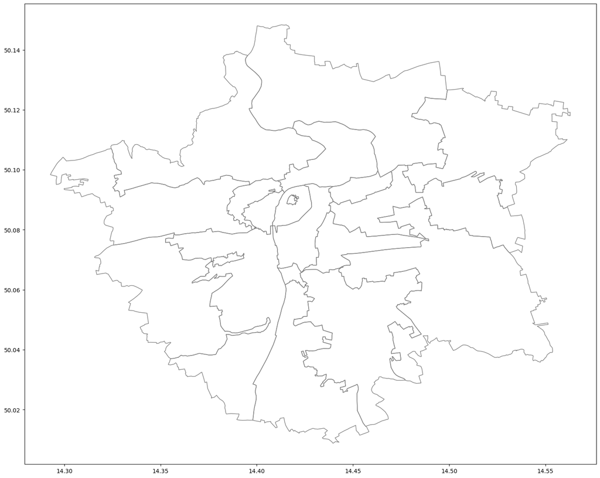

```python
districts.plot(facecolor="none", edgecolor='grey', figsize=(18, 18))
```

### Načtení bydlišť před deportací

```python
houses = ehri_wfs("MGS-prague_jewish_residency_during_occupation-v1-eng")
houses.head()
```

|  | geometry | address_en | address_de | count | murdered | survived | fate_unknown | present_1942-01-01 | present_1943-01-01 | present_1944-01-01 | present_1945-01-01 | present_1945-05-09 |
| --- | --- | --- | --- | --- | --- | --- | --- | --- | --- | --- | --- | --- |
| 0 | POINT (14.457 50.039) | Prague XIV, Budějovická 93 | Prag XIV, Budweiser Strasse 93 | 4 | 3 | 0 | 1 | 3 | 0 | 0 | 0 | 0 |
| 1 | POINT (14.435 50.039) | Prague XIV, Nová cesta 9/510 | Prag XIV, Neuer Weg 9/510 | 3 | 3 | 0 | 0 | 3 | 0 | 0 | 0 | 0 |
| 2 | POINT (14.411 50.039) | Prague XV, Branická 19/722 | Prag XV, Braniker Strasse 19/722 | 13 | 10 | 0 | 3 | 7 | 1 | 1 | 0 | 0 |
| 3 | POINT (14.451 50.041) | Prague XIV, K Habrovce 85 | Prag XIV, Zu den Hainbuchen 85 | 6 | 6 | 0 | 0 | 5 | 2 | 0 | 0 | 0 |
| 4 | POINT (14.479 50.041) | Prague XIII, Jihozápadní IV 2321 | Prag XIII, Südweststrasse 2321 | 5 | 5 | 0 | 0 | 4 | 0 | 0 | 0 | 0 |

### Načtení datasetu Stolpersteinů

```python
stolpersteine = ehri_wfs("STS-stolpersteine_prague-v2_20230930")
stolpersteine.head()
```

|  | geometry | id | person | address_cs | address_en | link_stolpersteine_cs | link_stolpersteine_en | link_holocaustcz_cs | link_holocaustcz_en |
| --- | --- | --- | --- | --- | --- | --- | --- | --- | --- |
| 0 | POINT (14.418 50.091) | 1 | Pollaková Eva Mia (* 1924) | Praha 1, 17. listopadu 207/6 | Prague 1, 17. listopadu 207/6 | http://stolpersteinecz.cz/mia-pollakova | http://stolpersteinecz.cz/en/mia-pollakova | https://www.holocaust.cz/databaze-obeti/obet/1... | https://www.holocaust.cz/en/database-of-victim... |
| 1 | POINT (14.418 50.091) | 2 | Pollaková Vilma (* 1897) | Praha 1, 17. listopadu 207/6 | Prague 1, 17. listopadu 207/6 | http://stolpersteinecz.cz/vilma-pollakova | http://stolpersteinecz.cz/en/vilma-pollakova/ | https://www.holocaust.cz/databaze-obeti/obet/1... | https://www.holocaust.cz/en/database-of-victim... |
| 2 | POINT (14.418 50.091) | 3 | Fahnová Helena (* 1919) | Praha 1, 17. listopadu 4-6 | Prague 1, 17. listopadu 4-6 | http://stolpersteinecz.cz/fahnova-helena | http://stolpersteinecz.cz/en/fahnova-helena | https://www.holocaust.cz/databaze-obeti/obet/8... | https://www.holocaust.cz/en/database-of-victim... |
| 3 | POINT (14.418 50.091) | 4 | Fahn Karel (* 1914) | Praha 1, 17. listopadu 4-6 | Prague 1, 17. listopadu 4-6 | http://stolpersteinecz.cz/fahn-karel | http://stolpersteinecz.cz/en/fahn-karel | https://www.holocaust.cz/databaze-obeti/obet/8... | https://www.holocaust.cz/en/database-of-victim... |
| 4 | POINT (14.418 50.091) | 5 | Markusová Berta (* 1887) | Praha 1, 17. listopadu 4-6 | Prague 1, 17. listopadu 4-6 | http://stolpersteinecz.cz/markusova-berta-roz-... | http://stolpersteinecz.cz/en/markusova-berta-r... | https://www.holocaust.cz/databaze-obeti/obet/1... | https://www.holocaust.cz/en/database-of-victim... |

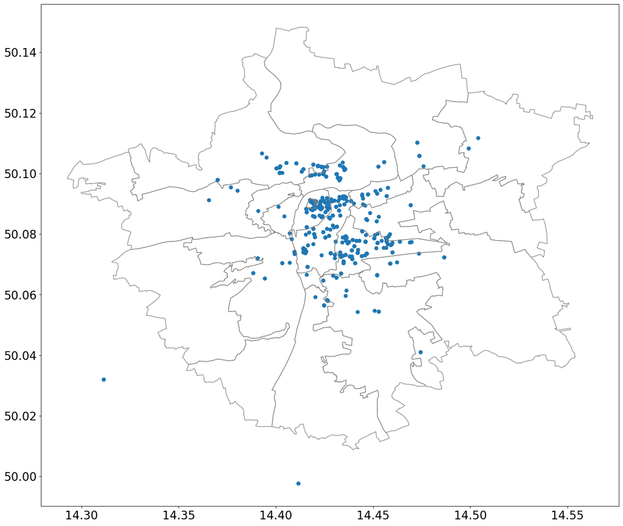

```python
fig, ax = plt.subplots(figsize=(18, 18))
stolpersteine.plot(ax=ax)
districts.plot(facecolor="none", edgecolor='grey', ax=ax)
```

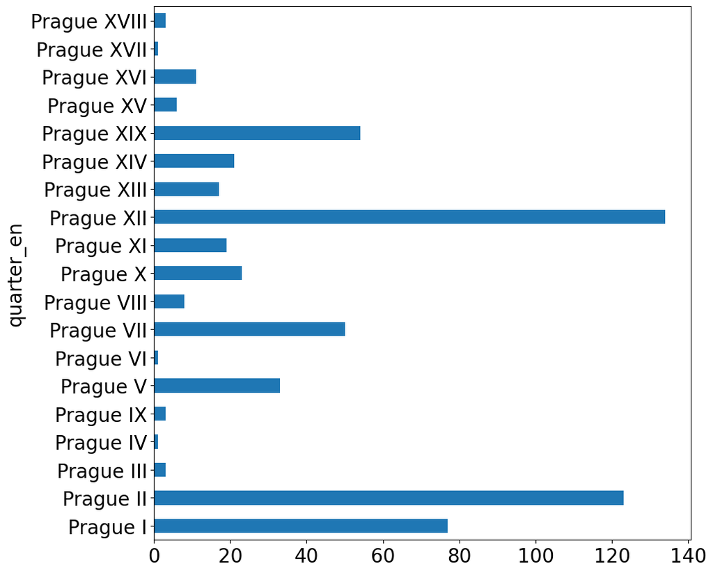

```python
dsgrouped = ds[["quarter_en"]].groupby(['quarter_en'])['quarter_en'].count()
dsgrouped.plot(kind="barh", figsize=(10, 10))
```

```python
hs = dhgrouped.join(dsgrouped, on="quarter_en")
hs.rename({'quarter_en': 'stolpersteine'}, axis=1, inplace=True)
hs['proportion'] = hs['stolpersteine'] / hs['murdered']
hs.sort_values(['proportion'], ascending=[False])
```

| quarter_en | murdered | stolpersteine | proportion |
| --- | --- | --- | --- |
| Prague XIX | 544 | 54 | 0.099265 |
| Prague VII | 1493 | 50 | 0.033490 |
| Prague III | 111 | 3 | 0.027027 |
| Prague XV | 238 | 6 | 0.025210 |
| Prague XIV | 884 | 21 | 0.023756 |
| Prague VI | 44 | 1 | 0.022727 |
| Prague IX | 134 | 3 | 0.022388 |
| Prague II | 5659 | 123 | 0.021735 |
| Prague V | 1692 | 33 | 0.019504 |
| Prague XII | 7001 | 134 | 0.019140 |
| Prague XVI | 654 | 11 | 0.016820 |
| Prague XVIII | 192 | 3 | 0.015625 |
| Prague IV | 70 | 1 | 0.014286 |
| Prague I | 5543 | 77 | 0.013891 |
| Prague X | 1975 | 23 | 0.011646 |
| Prague VIII | 807 | 8 | 0.009913 |
| Prague XI | 2248 | 19 | 0.008452 |
| Prague XIII | 2022 | 17 | 0.008408 |
| Prague XVII | 122 | 1 | 0.008197 |

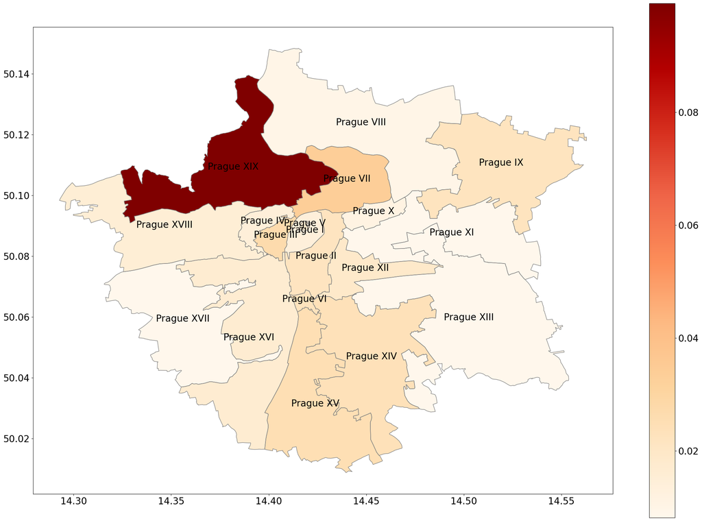

```python
diststat = districts.merge(hs, on='quarter_en', how='left')
fig, ax = plt.subplots(figsize = (28, 20))
diststat[(diststat["murdered"]>0)].plot(cmap="OrRd", column="proportion", legend=1, ax=ax)
diststat.apply(lambda x: ax.annotate(text=x['quarter_en'], xy=x.geometry.centroid.coords[0], ha='center'),axis=1); #  + ': ' + str(x['stolpersteine']) + '/' + str(x['murdered'])
districts.plot(facecolor="none", edgecolor='grey', ax=ax)
```

## Porovnání bydlišť před deportací (nalevo) a Stolpersteinů (napravo)

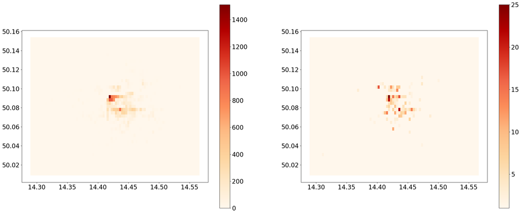

```python
fig, axes = plt.subplots(nrows=1, ncols=2, figsize=(30, 12))

gridh3.plot(figsize = (28, 20), cmap="OrRd", column="murdered", legend=1, ax=axes[0])
grids3.plot(figsize = (28, 20), column="geometry_right", cmap="OrRd", legend=1, ax=axes[1])
```